# What’s wrong with my plot?

## What this resource is:

A beginner’s guide to what can go wrong when visualising data using `ggplot2` in R. It covers some of the most common reasons why a `ggplot2` plot looks different or less informative from what you expected e.g. wrong number of groups appearing, unexpected ordering, missing lines, collapsed categories etc.

## What this resource is not:

*Styling and appearance* - colours, backgrounds, gridlines, fonts, themes, or formatting of axis labels, titles, captions, and annotations. There are many resources for this, including the free [ggplot2: Elegant Graphics for Data Analysis](https://ggplot2-book.org/) and [R Graphics Cookbook](https://r-graphics.org/) books, as well as package specific documentation such as [ggplot2 package](https://ggplot2.tidyverse.org/).

*Choosing the right plot for your data* - there are excellent resources to guide you on this, such as the [R-Graph Gallery](https://r-graph-gallery.com/) and from [Data to Viz](https://www.data-to-viz.com/). That said, many of the issues covered within this guide stem from data not being in the right format to begin with so it is worth checking whether your variables are correctly represented as numeric, factor, character, or date etc. before assuming the problem lies in your `ggplot2` code.

## Examples of charts that could be improved

#### Scan through the plot examples below and click on the links after each plot to take you to that section.

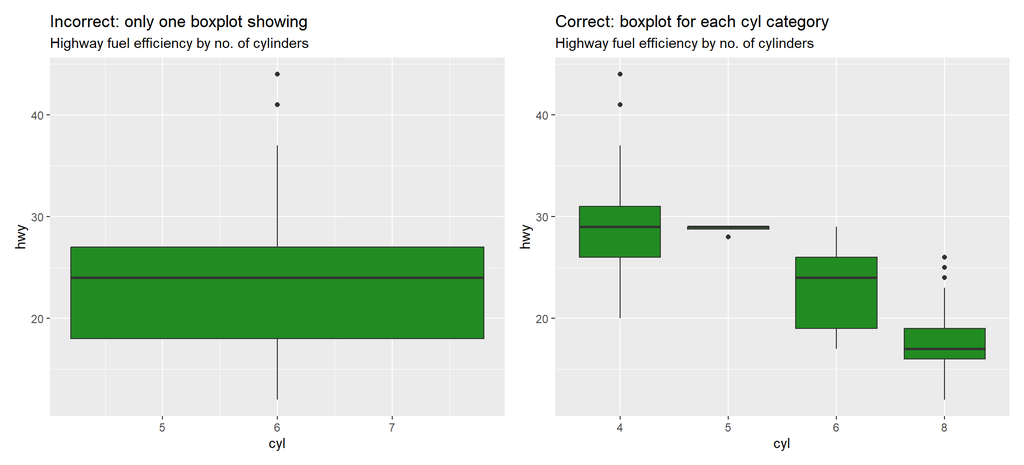

#### See incorrect variable type

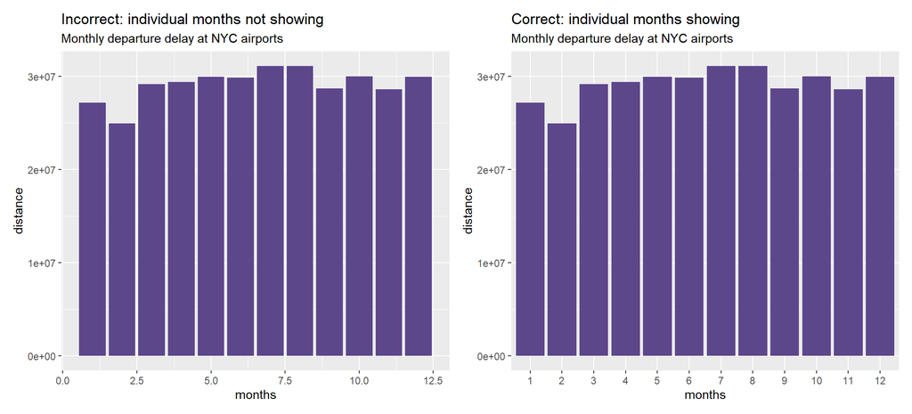

#### See incorrect variable type

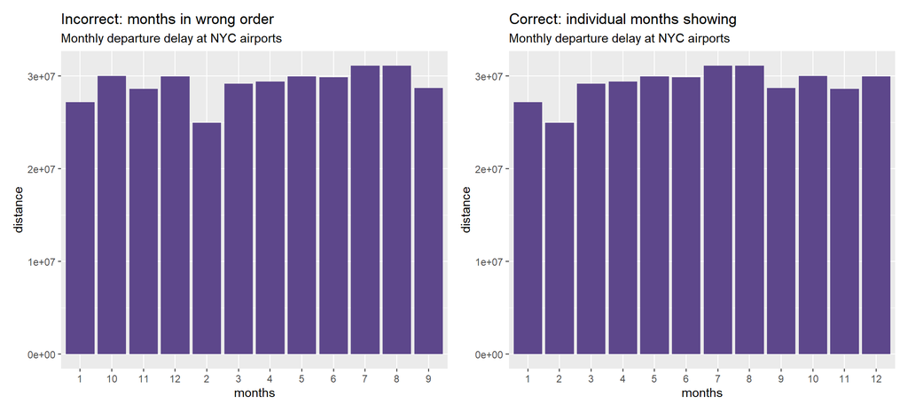

#### See incorrect variable type

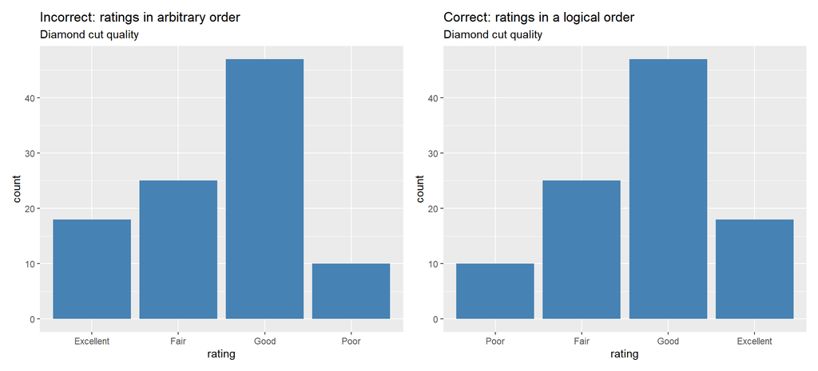

#### See ordering factors

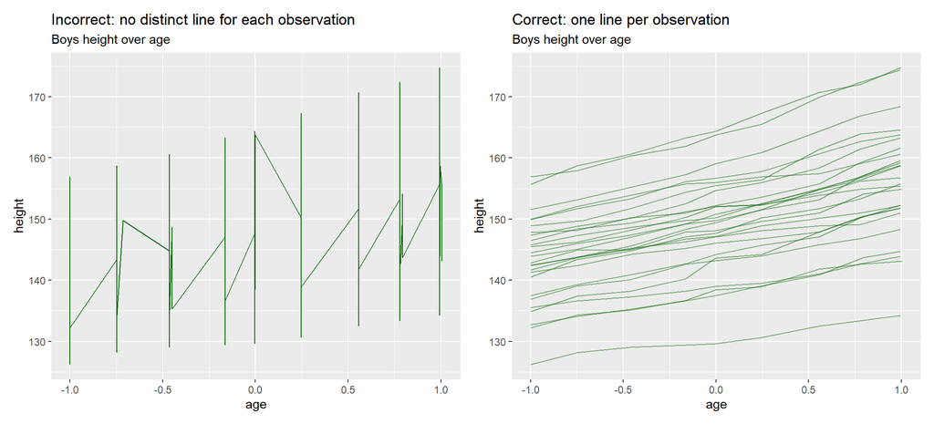

#### See Line charts not giving distinct lines

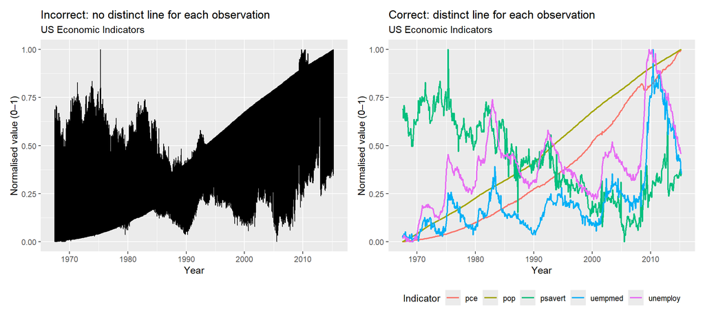

#### See Line charts not giving distinct lines

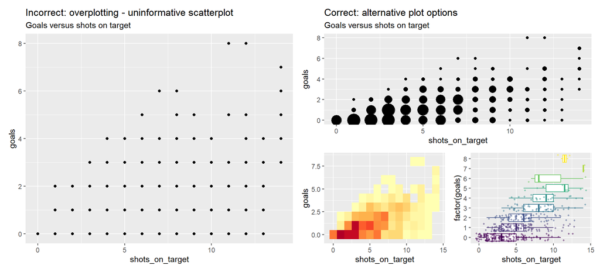

#### See Overplotting

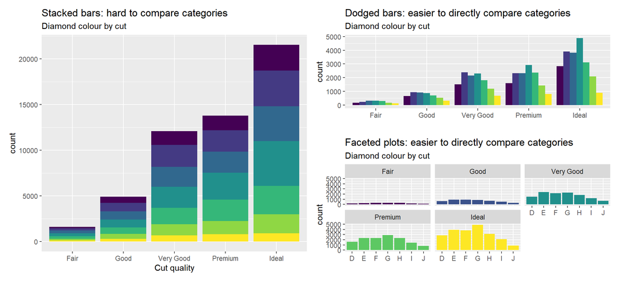

#### See Alternative to stacked bar charts

## Not enough categories in the boxplot

#### Reason: Wrong variable type

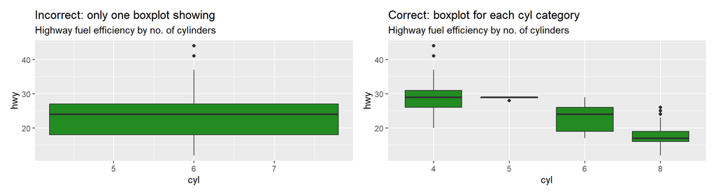

A common issue arises when a grouping variable is numeric but should be treated as a category. R sees an integer column and maps it to a continuous axis, often collapsing groups or producing a single box instead of one per group.

This pattern comes up in several common situations, for example:

- discrete counts such as cylinders or gears or other discrete counts - the values are numbers but the meaningful comparison is between groups, not along a numeric scale.
- a small number of years - treating year as a factor gives one box per year and a clean categorical axis.
- survey scales such as Likert responses - these are often better visualised as ordered categories than as a continuous variable.

In general if the distance between numeric values doesn’t carry meaning in your plot, convert the numeric value to a categorical factor variable.

We can demonstrate by looking at a classic example of plotting highway fuel efficiency (`hwy`) by number of cylinders (`cyl`) from the built-in `mpg` dataset. Although `cyl` only takes four values (4, 5, 6, 8), R treats it as a continuous numeric variable by default, which can result in unexpected behaviour on the x-axis.

The code below looks correct, but because the variable is the wrong type we don’t see boxplots for each `cyl` category:

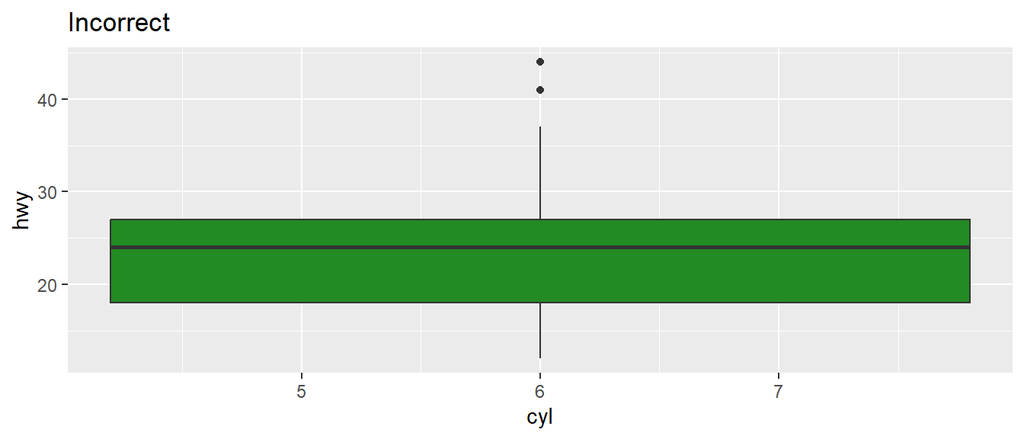

```r
ggplot(mpg, aes(x = cyl, y = hwy)) +
  geom_boxplot(fill = "forestgreen")
```

The `ggplot2` message after running this code suggests using a group argument. We can try this:

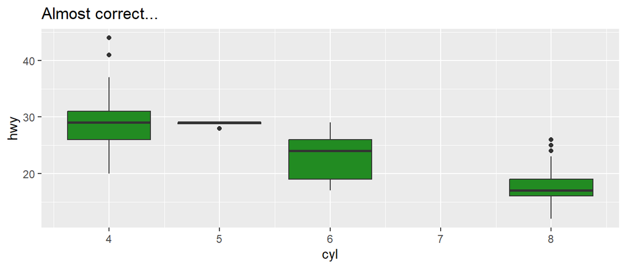

```r
ggplot(mpg, aes(x = cyl, y = hwy, group = cyl)) + # add grouping variable
  geom_boxplot(fill = "forestgreen")
```

However in this plot we also get a space for 7 cylinders, even though no 7 cylinder cars are included in the data.

The issue with both these approaches is that the `cyl` variable is being treated as numeric. We can check this:

```r
class(mpg$cyl) # check class of cyl variable
```

```
## [1] "integer"
```

In the incorrect plots, the `cyl` variable is being treated as a numeric variable resulting in a continuous x-axis rather than a separate box for each cylinder group. Converting `cyl` to a factor variable resolves this, giving one boxplot per group as expected.

In the correct plot, the `cyl` variable is treated as categorical variable (a factor), and we can now clearly see the distribution of highway fuel efficiency for each number of cylinders.

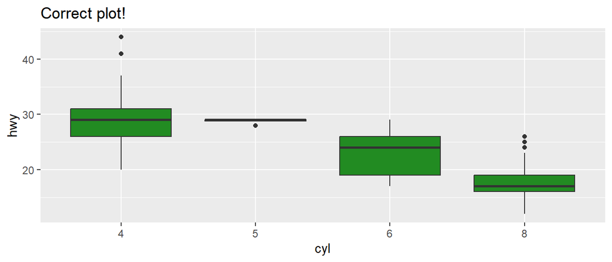

```r
mpg_updated <- mpg %>%
  mutate(cyl = factor(cyl)) # change variable to factor

ggplot(mpg_updated, aes(x = cyl, y = hwy)) + # use updated data
  geom_boxplot(fill = "forestgreen")
```

## Variable in wrong order

#### Reason: Wrong variable type

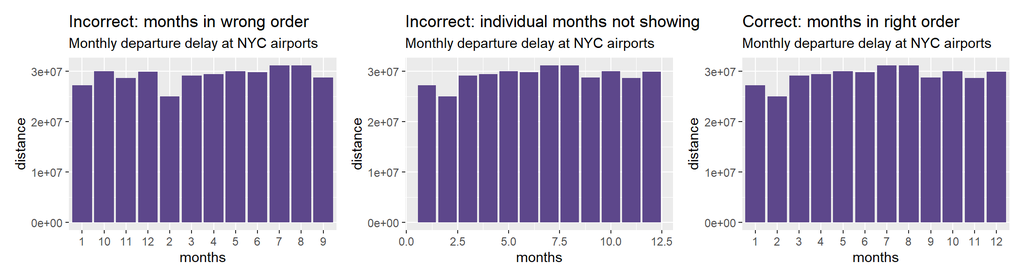

Another issue that can arise when the variable appears numeric but should be treated as categorical is that the bars in a bar chart appear in the wrong order, or the axis labels aren’t as expected. A good example is plotting months of the year, represented in the data as the numbers 1-12. The behaviour differs depending on how R interprets the variable.

- character - the months are sorted alphabetically by their string value, so 1, 10, 11, 12 appear before 2,3,4 and so on.
- numeric - rather than a label for each month, `ggplot2` produces a continuous scale, and may not place a tick at every integer.
- factor - the months correctly ordered and labelled, 1 through 12. Note we can also supply meaningful labels within the `factor()` call to display month names instead of numbers

```r
# to get the flights data
library(nycflights13)
# inspect data frame
flights
```

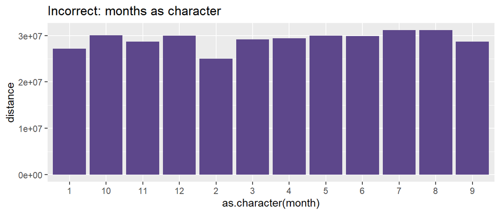

```r
# month variable as character
ggplot(flights, aes(x = as.character(month), y = distance)) +
  geom_col(fill = "mediumpurple4")
```

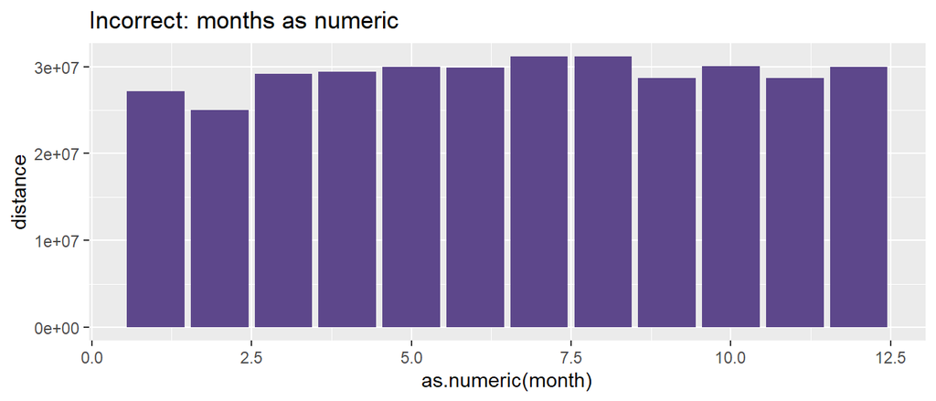

```r
# month variable as numeric
ggplot(flights, aes(x = as.numeric(month), y = distance)) +
  geom_col(fill = "mediumpurple4")
```

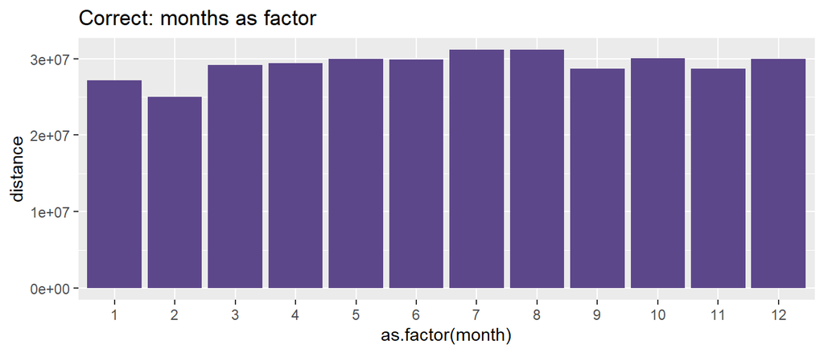

```r
# month variable as factor
ggplot(flights, aes(x = as.factor(month), y = distance)) +
  geom_col(fill = "mediumpurple4")
```

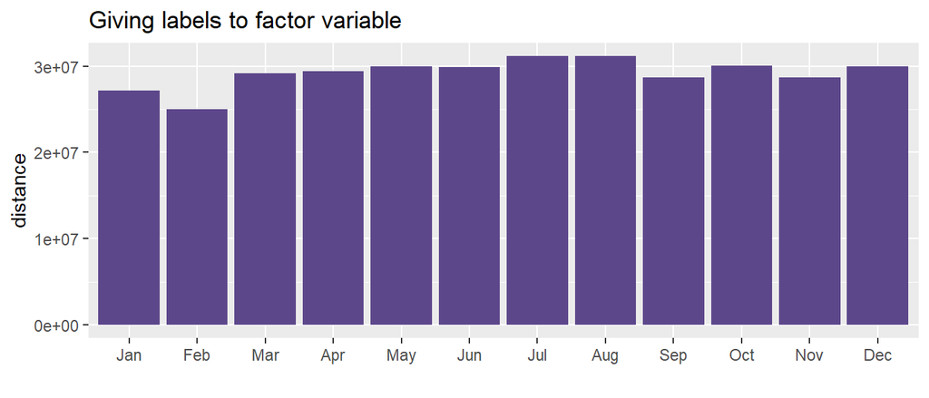

```r
# add month labels to the month factor
flights$monthnames <- factor(flights$month, levels = 1:12, labels = month.abb)
# month variable as labelled factor
ggplot(flights, aes(x = monthnames, y = distance)) +
  geom_col(fill = "mediumpurple4") +
  labs(x = "")
```

## Variable in wrong order

#### Reason: Factor levels not specified

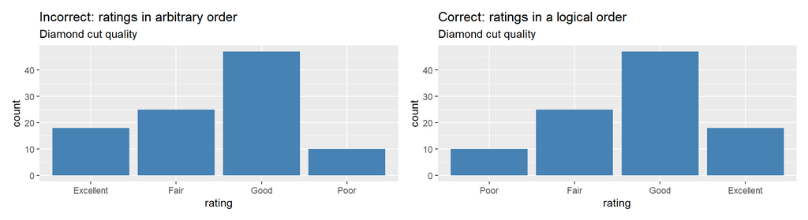

Sometimes when plotting data, the order of bars or boxplots may not be logical or meaningful. By default, `ggplot2` will order categorical variables alphabetically.

To demonstrate, we create a small example data frame with four quality rating categories. In the plot below the ratings appear in alphabetical order, which doesn’t reflect their natural ranking.

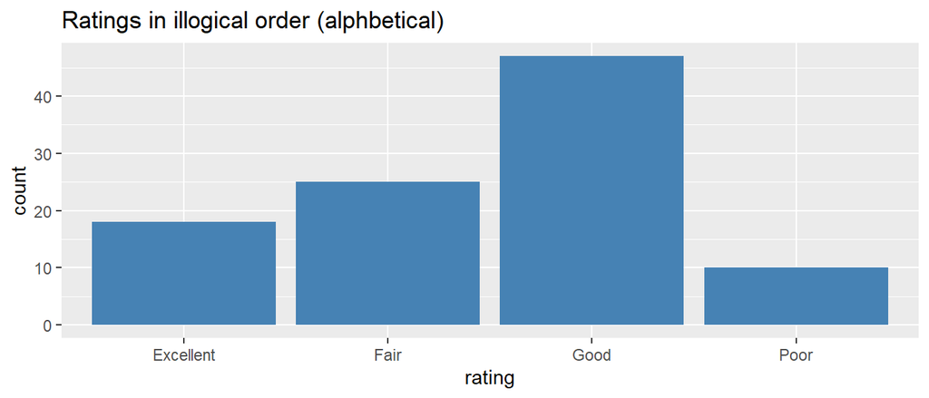

```r
# make dummy data frame with ratings
rating_df  <- data.frame(
  rating = c("Poor", "Fair", "Good", "Excellent"),
  count  = c(10, 25, 47, 18)
)

# plot bar chart of ratings data frame
ggplot(rating_df, aes(x = rating, y = count)) +
  geom_bar(stat = "identity", fill = "steelblue")
```

We can use the levels argument within the `factor()` function to specify the desired order:

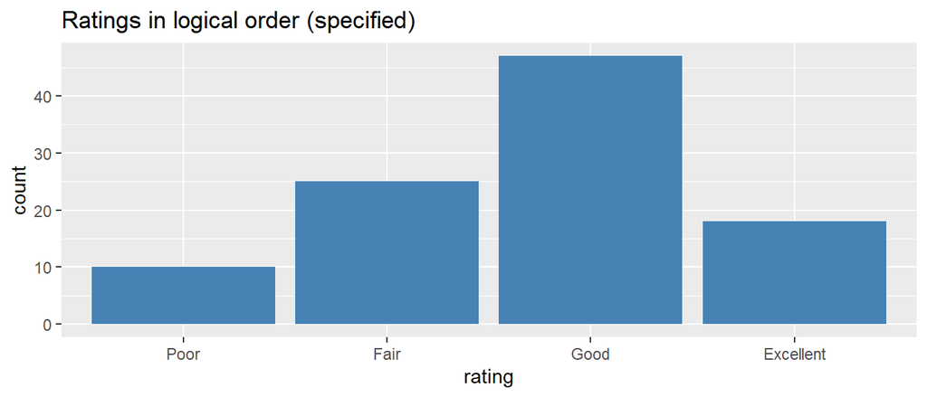

```r
# make an ordered factor - specify the levels
rating_df$rating <- factor(rating_df$rating, levels = c("Poor", "Fair", "Good", "Excellent"))

# plot bar chart of ratings data frame
ggplot(rating_df, aes(x = rating, y = count)) +
  geom_bar(stat = "identity", fill = "steelblue")
```

The bars now appear in a logical order that reflects the underlying scale of the categories.

## Line charts not giving distinct lines

#### Reason: Missing or wrong aesthetic mapping

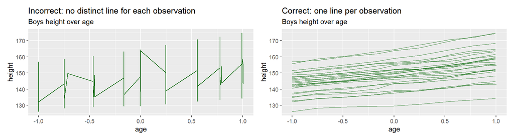

When plotting a line graph, each line typically represents one entity or group, for example, an individual child, a single subject, a team, or country tracked over time. If lines don’t appear as expected, the cause is often a missing or incorrect aesthetic mapping passed to `ggplot()`.

As well as `x` and `y`, line graphs usually require a `group` aesthetic to tell `ggplot2` which observations belong to the same line. If group is omitted, `ggplot2` may connect all points into a single jagged line rather than drawing one line per entity.

To demonstrate this we’ll use the `Oxboys` data frame from the `nlme` package, which contains the height of a sample of boys measured at different ages.

```r
# to get the Oxford boys data
library(nlme)
# inspect data frame
Oxboys
```

Without specifying a `group` or `colour` aesthetic, `geom_line()` has no way of knowing which observations belong to the same subject.

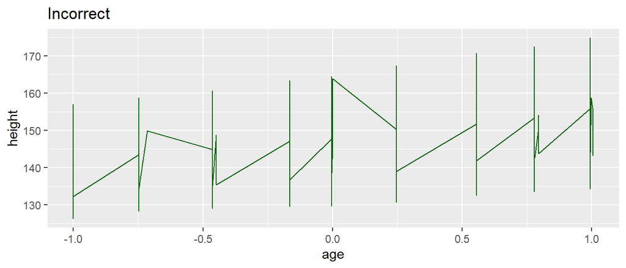

```r
# plotting without any colour aesthetic
ggplot(Oxboys, aes(x = age, y = height)) +
  geom_line(colour = "darkgreen")
```

We can set the `group` aesthetic explicitly, or we can use the `colour` aesthetic to implicitly define the groups as `ggplot2` will automatically draw a separate line for each unique value of the colour variable. In this example we set the `group()` aesthetic to `Subject`, as we are interested in the overall trend across all boys rather than the differences between the different subjects.

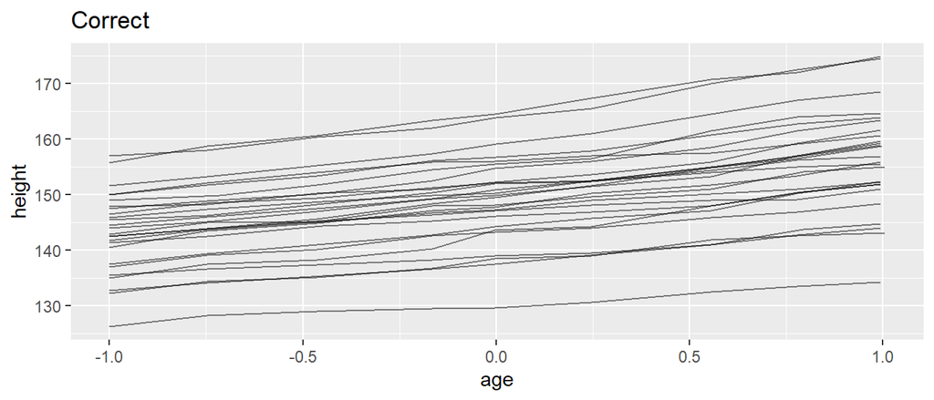

[figure not shown]

```r
ggplot(Oxboys, aes(x = age, y = height, group = Subject)) + # could alternatively set colour = Subject
  geom_line(alpha = 0.5) +
  labs(title = "Correct")
```

We can see the same issue using the built-in `economics_long` dataset, which contains five US economic indicators tracked over time, normalised to a 0–1 scale for comparison. Without a `group` or `colour` aesthetic, `ggplot2` connects all observations into a single line regardless of which indicator they belong to, producing an uninformative and cluttered result

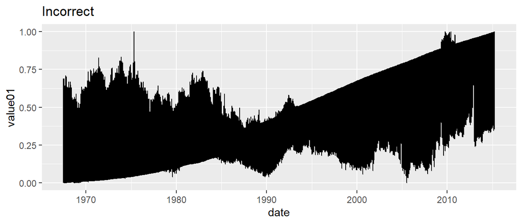

```r
ggplot(economics_long, aes(x = date, y = value01)) +
  geom_line()
```

Setting `colour = variable` implicitly groups the data, giving each economic indicator its own distinct line and making trends across indicators easy to compare.

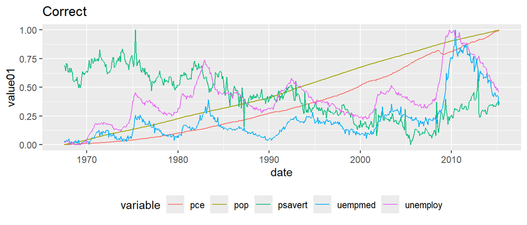

```r
ggplot(economics_long, aes(x = date, y = value01, colour = variable)) +
  geom_line()
```

## Overplotting

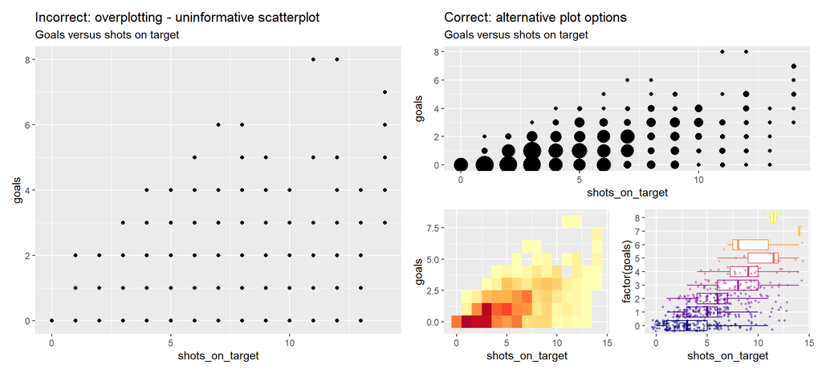

When both variables take a small range of integer values, a standard scatterplot suffers from severe overplotting — many points occupy exactly the same coordinates and are plotted directly on top of one another, making it impossible to judge how many observations share a given (shots, goals) pair.

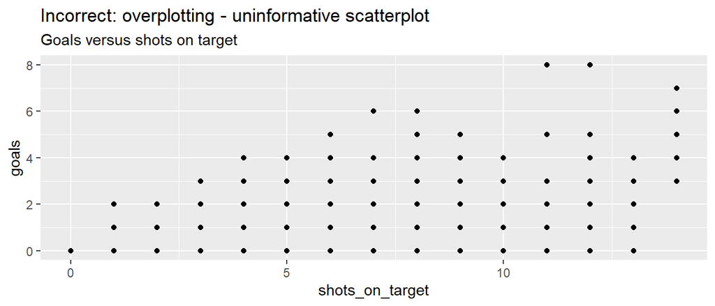

```r
ggplot(football_data, aes(x = shots_on_target, y = goals)) +
  geom_point() +  # massive overplotting, many points invisible
  labs(title = "Incorrect: overplotting - uninformative scatterplot", subtitle = 'Goals versus shots on target')
```

One solution is to use `geom_count()`, which replaces individual points with circles whose area is proportional to the number of observations at that location.

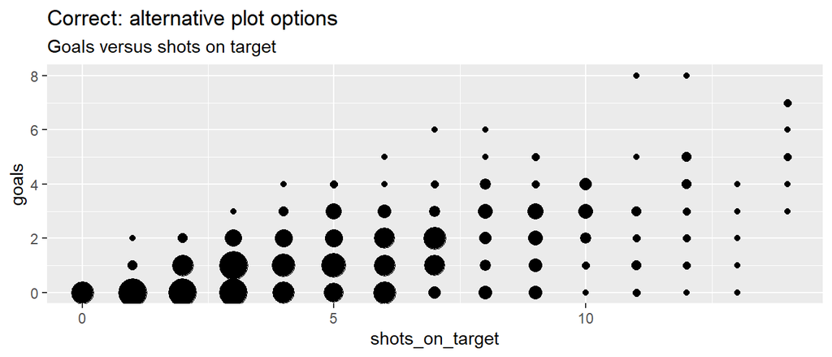

```r
ggplot(football_data, aes(x = shots_on_target, y = goals)) +
  geom_count() +
   scale_size_area(max_size = 8) +
  theme(legend.position = "none") +
  labs(title = "Correct: alternative plot options", subtitle = 'Goals versus shots on target')
```

A heatmap tile plot is another effective alternative. The data is first summarised into counts for each (shots, goals) combination, then a colour scale is used to encode the frequency.

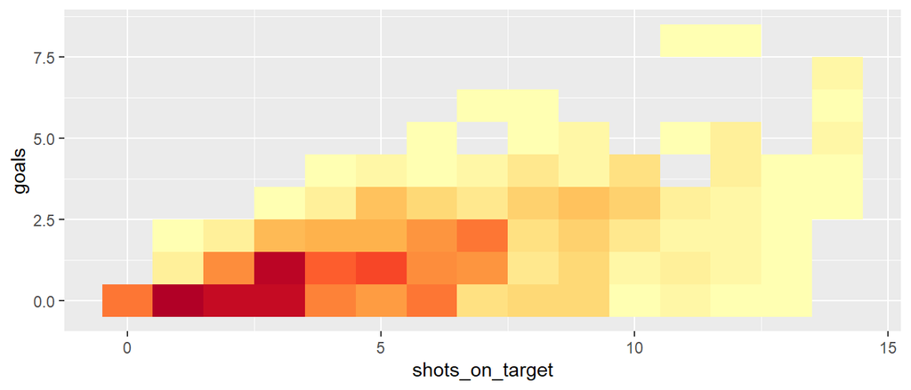

```r
football_data %>%
  count(shots_on_target, goals) %>%
  ggplot(aes(x = shots_on_target, y = goals, fill = n)) +
  geom_tile() +
  scale_fill_distiller(palette = "YlOrRd", direction = 1) +
  theme(legend.position = "none")
```

A boxplot with jittered points takes a different approach — treating goals as the grouping variable and showing the full distribution of shots on target within each group. The jitter reveals the density of observations while the boxplot summarises the median and spread, giving both detail and structure in a single plot.

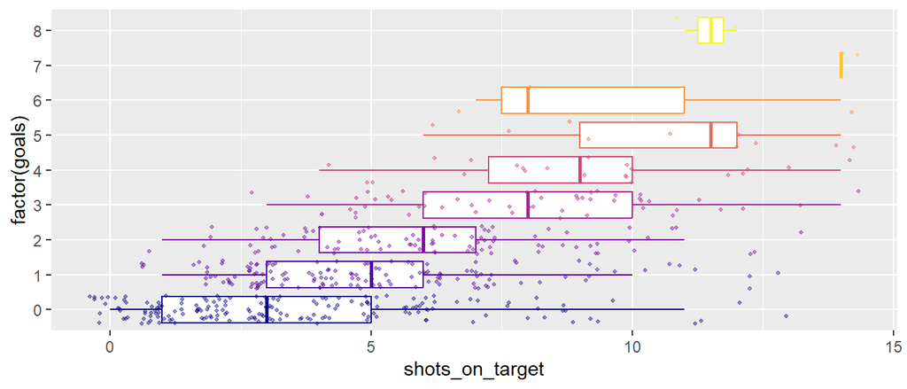

```r
ggplot(football_data, aes(x = shots_on_target, y = factor(goals), colour = goals)) +
  geom_boxplot(outlier.shape = NA,            ) +
  geom_jitter(alpha = 0.45, size = 0.8) +
   scale_colour_viridis_c(option = "plasma", guide = "none")
```

No single approach here is universally better than the others, the right choice depends on the story you want to tell with your data and which features of that data you most want to highlight.